# Assignment 3

YAP MING YAN (68103)

MARK HARLEY JONATHAN J KILONG JR (66579)

MUHAMMAD ALIF BIN AZIZ (64915)

26 July, 2022

```r
# read data from text file
senic = read.table("Senic.txt")
```

```r
# assign variable names to senic dataframe
names(senic) = c("i",
                 "Length of stay",
                 "Age",
                 "Infection risk",
                 "Routine culturing ratio",
                 "Routine chest X-ray ratio",
                 "No. of beds",
                 "Medical school affiliation",
                 "Region",
                 "Average daily census",
                 "No. of nurses",
                 "Available facilities and services"
                 )

# region as categorical data
senic$Region = factor(senic$Region)
```

#Part I  
a.Obtain a random sample of 100 cases (or 90%) from the 113 cases in this data set. Attach this random sample data to your answer for reference

```r
set.seed(4)
random_sample_data = senic[sample(nrow(senic), 100), ]

knitr::kable(random_sample_data, col.names = NULL)
```

| 75 | 75 | 8.45 | 38.8 | 3.4 | 12.9 | 85.0 | 235 | 2 | 2 | 143 | 124 | 48.6 |
| --- | --- | --- | --- | --- | --- | --- | --- | --- | --- | --- | --- | --- |
| 51 | 51 | 11.48 | 57.6 | 5.6 | 20.3 | 82.0 | 252 | 2 | 1 | 207 | 251 | 51.4 |
| 3 | 3 | 8.34 | 56.9 | 2.7 | 8.1 | 74.0 | 107 | 2 | 3 | 82 | 54 | 20.0 |
| 71 | 71 | 7.39 | 51.0 | 4.2 | 14.6 | 88.4 | 72 | 2 | 2 | 38 | 67 | 28.6 |
| 44 | 44 | 10.12 | 51.7 | 5.6 | 14.9 | 79.1 | 362 | 1 | 3 | 313 | 264 | 54.3 |
| 58 | 58 | 7.65 | 47.1 | 4.3 | 16.4 | 65.7 | 318 | 2 | 4 | 265 | 314 | 51.4 |
| 112 | 112 | 17.94 | 56.2 | 5.9 | 26.4 | 91.8 | 835 | 1 | 1 | 791 | 407 | 62.9 |
| 56 | 56 | 11.15 | 56.5 | 3.9 | 7.7 | 73.9 | 281 | 2 | 1 | 217 | 199 | 51.4 |
| 30 | 30 | 9.89 | 50.5 | 4.9 | 17.7 | 103.6 | 167 | 2 | 2 | 113 | 106 | 37.1 |
| 62 | 62 | 11.18 | 51.0 | 5.7 | 18.8 | 55.9 | 595 | 1 | 2 | 546 | 392 | 68.6 |
| 102 | 102 | 9.89 | 45.2 | 4.3 | 11.8 | 108.7 | 190 | 2 | 1 | 141 | 112 | 42.9 |
| 2 | 2 | 8.82 | 58.2 | 1.6 | 3.8 | 51.7 | 80 | 2 | 2 | 51 | 52 | 40.0 |
| 24 | 24 | 9.84 | 62.2 | 4.8 | 12.0 | 82.3 | 600 | 2 | 3 | 468 | 497 | 57.1 |
| 1 | 1 | 7.13 | 55.7 | 4.1 | 9.0 | 39.6 | 279 | 2 | 4 | 207 | 241 | 60.0 |
| 84 | 84 | 8.77 | 54.5 | 4.7 | 5.2 | 47.0 | 143 | 2 | 4 | 85 | 87 | 25.7 |
| 35 | 35 | 9.74 | 54.4 | 6.3 | 11.4 | 76.1 | 221 | 2 | 2 | 170 | 172 | 54.3 |
| 27 | 27 | 9.31 | 47.2 | 4.5 | 30.2 | 101.3 | 170 | 2 | 1 | 124 | 173 | 37.1 |
| 48 | 48 | 10.90 | 57.2 | 5.5 | 10.6 | 71.9 | 593 | 2 | 2 | 446 | 211 | 51.4 |
| 96 | 96 | 8.54 | 56.1 | 2.5 | 27.0 | 82.5 | 98 | 2 | 1 | 57 | 75 | 45.7 |
| 103 | 103 | 7.14 | 57.6 | 2.7 | 13.1 | 92.6 | 92 | 2 | 4 | 40 | 50 | 22.9 |
| 32 | 32 | 9.84 | 53.0 | 5.2 | 17.7 | 72.6 | 210 | 2 | 2 | 200 | 239 | 54.3 |
| 47 | 47 | 19.56 | 59.9 | 6.5 | 17.2 | 113.7 | 306 | 2 | 1 | 273 | 172 | 51.4 |
| 109 | 109 | 11.80 | 53.8 | 5.7 | 9.1 | 116.9 | 571 | 1 | 2 | 441 | 469 | 62.9 |
| 69 | 69 | 9.61 | 52.4 | 4.5 | 6.9 | 87.2 | 487 | 2 | 3 | 404 | 220 | 48.6 |
| 15 | 15 | 9.00 | 56.3 | 4.2 | 14.6 | 76.4 | 72 | 2 | 3 | 61 | 38 | 17.1 |
| 22 | 22 | 10.24 | 49.0 | 4.8 | 36.3 | 112.6 | 195 | 2 | 2 | 163 | 170 | 37.1 |
| 90 | 90 | 11.41 | 50.4 | 5.8 | 23.8 | 73.0 | 424 | 1 | 3 | 359 | 335 | 45.7 |
| 64 | 64 | 9.66 | 52.1 | 4.4 | 9.9 | 98.3 | 83 | 2 | 2 | 66 | 95 | 28.6 |
| 49 | 49 | 7.67 | 51.7 | 1.8 | 2.5 | 40.4 | 106 | 2 | 3 | 93 | 35 | 11.4 |
| 54 | 54 | 12.07 | 43.7 | 7.8 | 52.4 | 105.3 | 157 | 2 | 2 | 115 | 76 | 31.4 |
| 113 | 113 | 9.41 | 59.5 | 3.1 | 20.6 | 91.7 | 29 | 2 | 3 | 20 | 22 | 22.9 |

[output cut: 69 more lines]

b.Prepare a histogram for each of the predictor variables. What information do these plots provide?

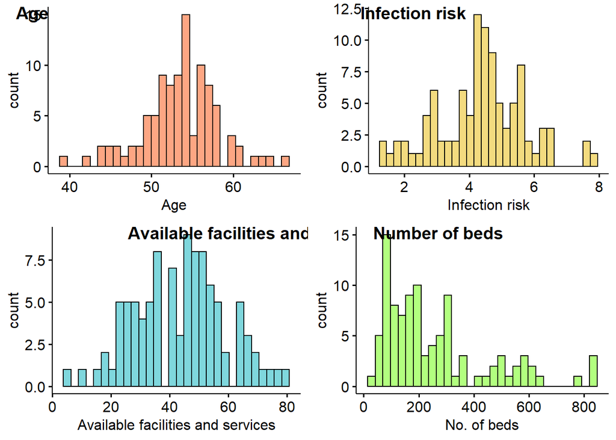

```r
p1 = gghistogram(random_sample_data, x = "Age", fill = "#FC4E07", bins = 30,)

p2 = gghistogram(random_sample_data, x = "Infection risk",
                 fill = "#E7B800", bins = 30,)

p3 = gghistogram(random_sample_data, x = "Available facilities and services",
                 fill = "#00AFBB", bins = 30,)

p4 = gghistogram(random_sample_data, x = "No. of beds",
                 fill = "#66FF00", bins = 30,)

ggarrange(p1, p2, p3, p4,
          labels = c("Age",
                     "Infection risk",
                     "Available facilities and services",
                     "Number of beds"),
          nrow = 2, ncol = 2
          )
```

The histogram plot of age is normally distributed.  
The histogram plot of infection risk is normally distributed.  
The histogram plot of available facilities and services is normally distributed. The histogram plot of number of beds is right shewed normal distribution.

c.Obtain the scatter plot matrix and the correlation matrix for each proposed model. Interpret these and state your principal findings.

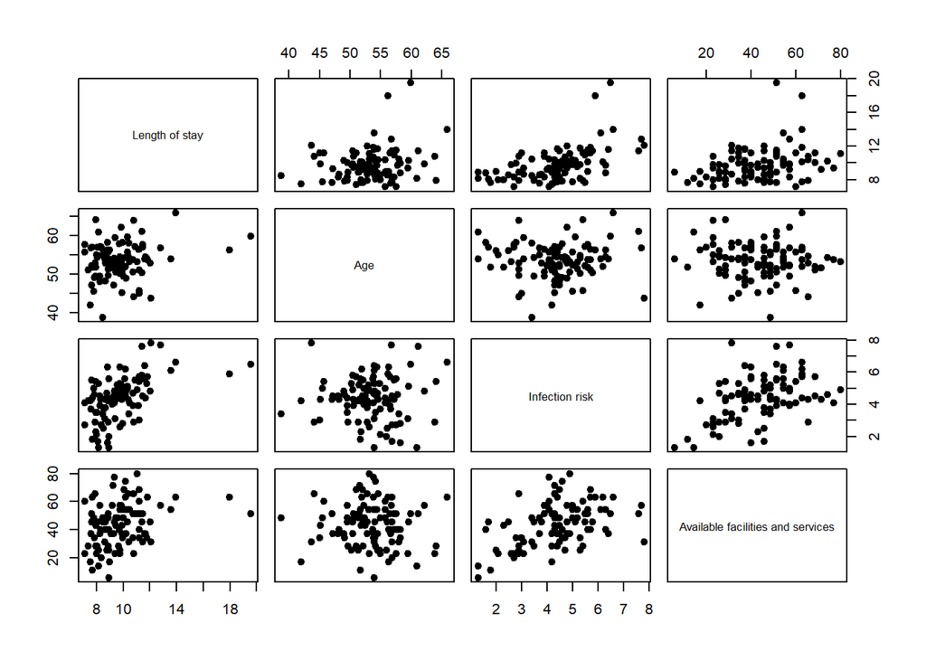

```r
# Model I
# scatter plot matrix
pairs(random_sample_data[, c(2, 3, 4, 12)], pch = 19)
```

```r
# correlation matrix
M1_CorrMatrix = cor(random_sample_data[, c(2, 3, 4, 12)])
colnames(M1_CorrMatrix) = c("Y", "X1", "X2", "X3")
M1_CorrMatrix
```

```
##                                           Y          X1         X2          X3
## Length of stay                    1.0000000  0.19436894 0.52221509  0.30853151
## Age                               0.1943689  1.00000000 0.01629006 -0.05830104
## Infection risk                    0.5222151  0.01629006 1.00000000  0.40821985
## Available facilities and services 0.3085315 -0.05830104 0.40821985  1.00000000
```

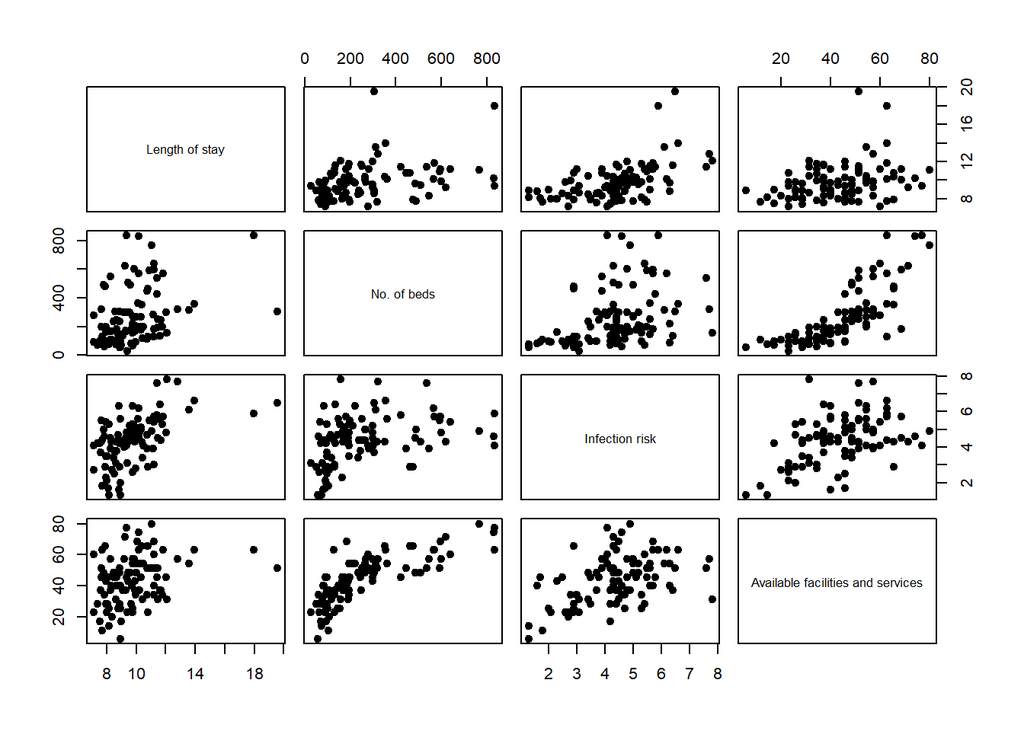

```r
# Model II
# scatter plot matrix
pairs(random_sample_data[, c(2, 7, 4, 12)], pch = 19)
```

```r
# correlation matrix
M2_CorrMatrix = cor(random_sample_data[, c(2, 7, 4, 12)])
colnames(M2_CorrMatrix) = c("Y", "X1", "X2", "X3")
M2_CorrMatrix
```

```
##                                           Y        X1        X2        X3
## Length of stay                    1.0000000 0.3798898 0.5222151 0.3085315
## No. of beds                       0.3798898 1.0000000 0.3629128 0.7816024
## Infection risk                    0.5222151 0.3629128 1.0000000 0.4082198
## Available facilities and services 0.3085315 0.7816024 0.4082198 1.0000000
```

The scatter plot matrix and correlation matrix for Model I shows that the length of stay (Y) has low correlation to Age(X1) and Available facilities and services(X3) but moderate correlation to Infection Risk(X2). Overall, the predictor variables are not strongly correlated to each other.

The scatter plot matrix and correlation matrix for Model II shows that the length of stay (Y) has low correlation to No. if beds(X1) and Available facilities and services(X3) but moderate correlation to Infection Risk(X2). However, the predictor variable No. of beds (X1) is highly correlated to Available facilities and services (X3). This implys that Model II exhibits multicollinearity and the redundant predictor variable should be dropped from the model.

4. For each of the two proposed models, fit first-order regression model

```r
# Model 1
M1_Y = random_sample_data$`Length of stay`
M1_X1 = random_sample_data$Age
M1_X2 = random_sample_data$`Infection risk`
M1_X3 = random_sample_data$`Available facilities and services`

M1_data = data.frame(M1_Y, M1_X1, M1_X2, M1_X3)

M1 = lm(M1_Y ~ M1_X1 + M1_X2 + M1_X3, M1_data) # Model I
M1_coef = coef(M1)
M1_coef
```

```
## (Intercept)       M1_X1       M1_X2       M1_X3
##  1.76238117  0.08142399  0.67072903  0.01635796
```

```r
# Model 2
M2_Y = random_sample_data$`Length of stay`
M2_X1 = random_sample_data$`No. of beds`
M2_X2 = random_sample_data$`Infection risk`
M2_X3 = random_sample_data$`Available facilities and services`

M2_data = data.frame(M2_Y, M2_X1, M2_X2, M2_X3)

M2 = lm(M2_Y ~ M2_X1 + M2_X2 + M2_X3, M2_data) # Model II
M2_coef = coef(M2)
M2_coef
```

```
## (Intercept)       M2_X1       M2_X2       M2_X3
##  6.73294266  0.00304463  0.66110563 -0.01480432
```

The estimated regression model for model I is:  
$Y =$ 1.7623812 + 0.081424$X1$ + 0.670729$X2$ + 0.016358$X3$

e.Calculate R2 for each model. Is one model clearly preferable in terms of this measure?

```r
# Model I
summary(M1)$r.squared
```

```
## [1] 0.3211815
```

```r
# Model II
summary(M2)$r.squared
```

```
## [1] 0.3195514
```

Model I $R^2:$ 0.3212  
Model II $R^2:$ 0.3196  
No. The coefficient of multiple determination $R^2$ for both Model I and Model II are relatively low. It is not significant to conclude one model is preferable than the other model.

6. For each model, obtain the residuals and plot them against $\hat{Y}$, each of the three predictor variables, and each of the two-factor interaction terms.

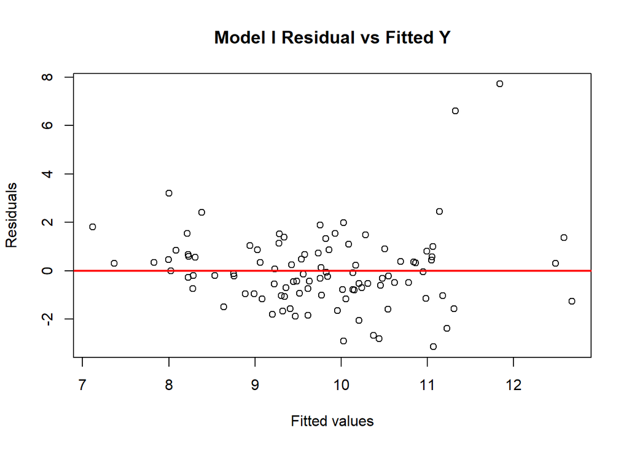

```r
# Model I
# Residual vs fitted Y
M1_fitted = fitted(M1)
M1_resid = resid(M1)
plot(M1_fitted, M1_resid,
     main = "Model I Residual vs Fitted Y",
     xlab = "Fitted values",
     ylab = "Residuals")
abline( h = 0 , lwd = 2, col = "red")
```

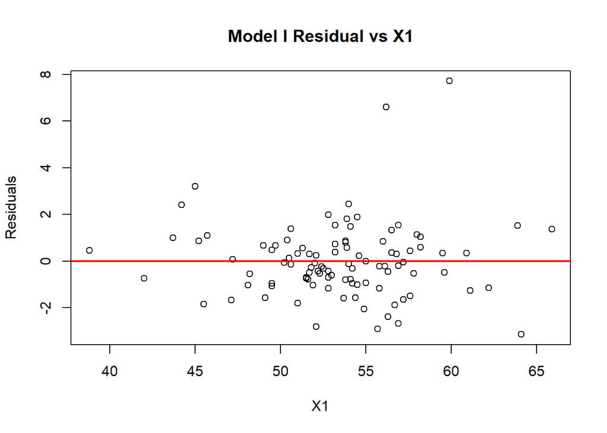

```r
# Residual vs X1
plot(M1_X1, M1_resid,
     main = "Model I Residual vs X1",
     xlab = "X1",
     ylab = "Residuals")
abline( h = 0 , lwd = 2, col = "red")
```

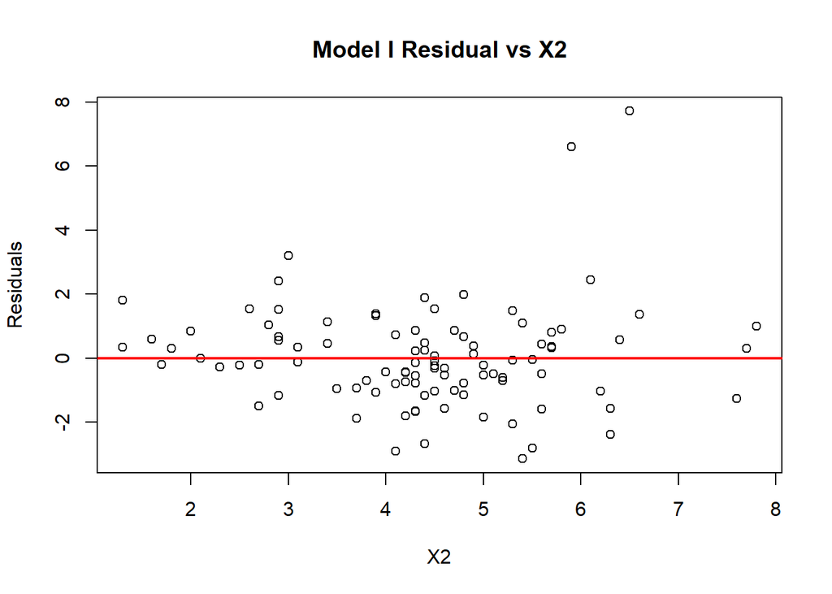

```r
# Residual vs X2
plot(M1_X2, M1_resid,
     main = "Model I Residual vs X2",
     xlab = "X2",
     ylab = "Residuals")
abline( h = 0 , lwd = 2, col = "red")
```

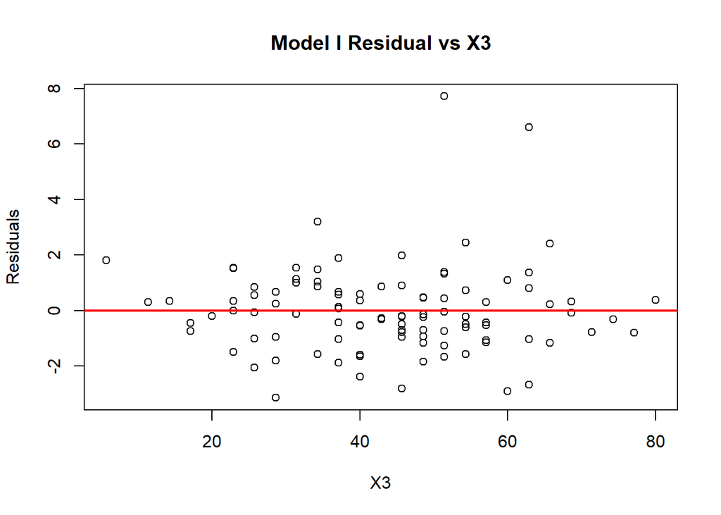

```r
# Residual vs X3
plot(M1_X3, M1_resid,
     main = "Model I Residual vs X3",
     xlab = "X3",
     ylab = "Residuals")
abline( h = 0 , lwd = 2, col = "red")
```

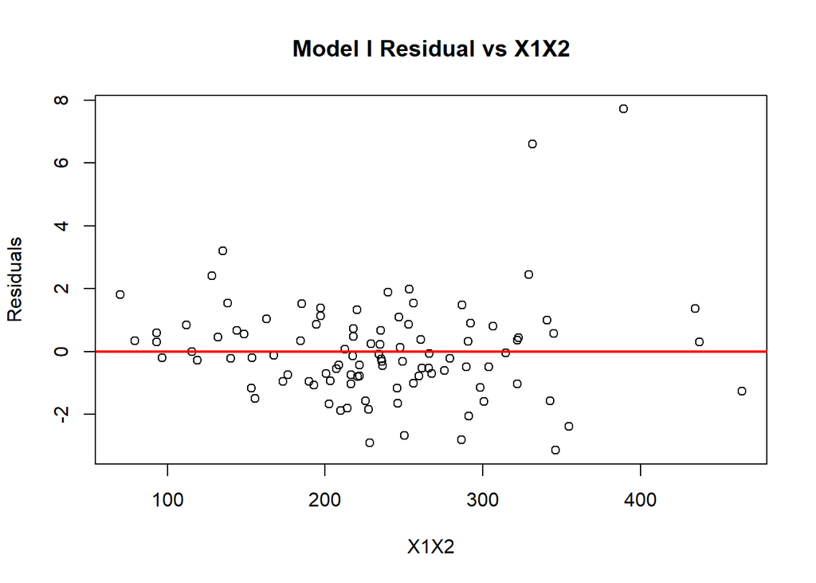

```r
# Residual vs X1X2
plot((M1_X1*M1_X2), M1_resid,
     main = "Model I Residual vs X1X2",
     xlab = "X1X2",
     ylab = "Residuals")
abline( h = 0 , lwd = 2, col = "red")
```

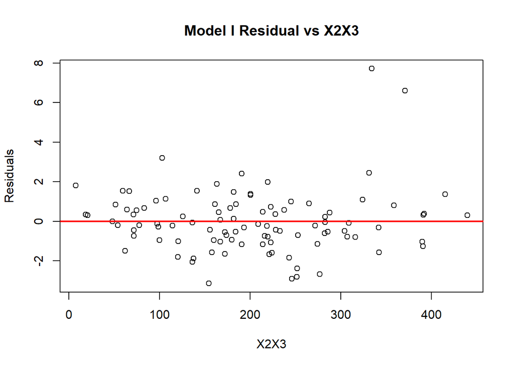

```r
# Residual vs X2X3
plot((M1_X2*M1_X3), M1_resid,
     main = "Model I Residual vs X2X3",
     xlab = "X2X3",
     ylab = "Residuals")
abline( h = 0 , lwd = 2, col = "red")
```

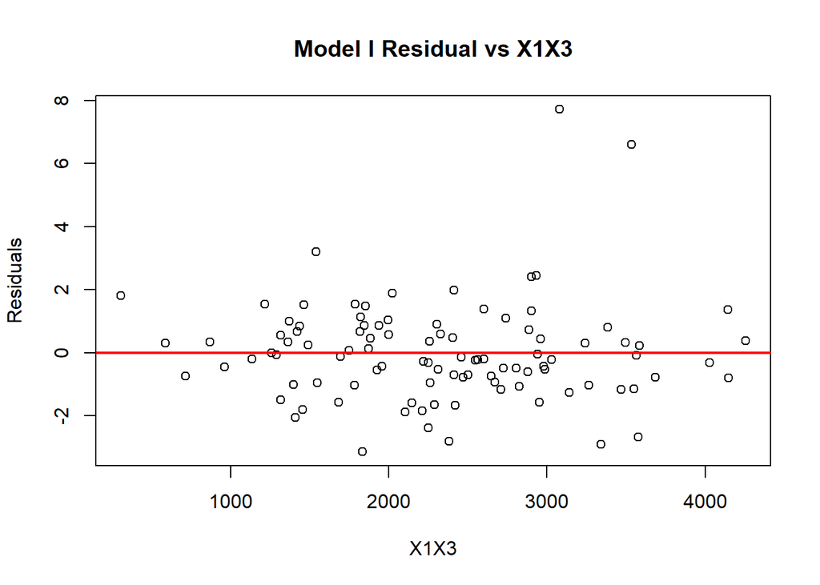

```r
# Residual vs X1X3
plot((M1_X1*M1_X3), M1_resid,
     main = "Model I Residual vs X1X3",
     xlab = "X1X3",
     ylab = "Residuals")
abline( h = 0 , lwd = 2, col = "red")
```

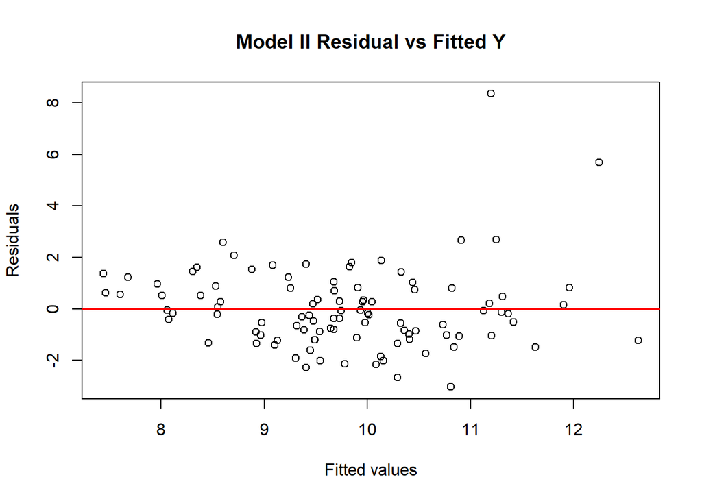

```r
# Model II
# Residual vs fitted Y
M2_fitted = fitted(M2)
M2_resid = resid(M2)
plot( M2_fitted,  M2_resid,
     main = "Model II Residual vs Fitted Y",
     xlab = "Fitted values",
     ylab = "Residuals")
abline( h = 0 , lwd = 2, col = "red")
```

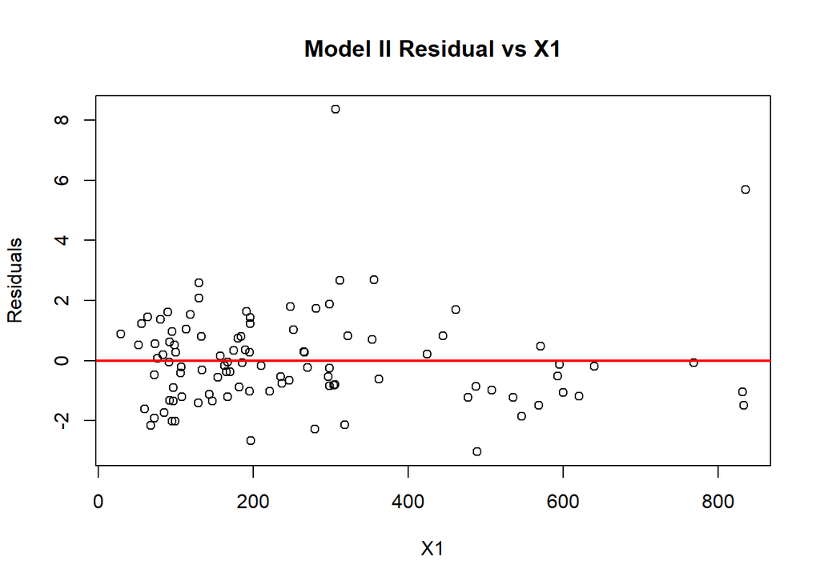

```r
# Residual vs X1
plot(M2_X1, M2_resid,
     main = "Model II Residual vs X1",
     xlab = "X1",
     ylab = "Residuals")
abline( h = 0 , lwd = 2, col = "red")
```

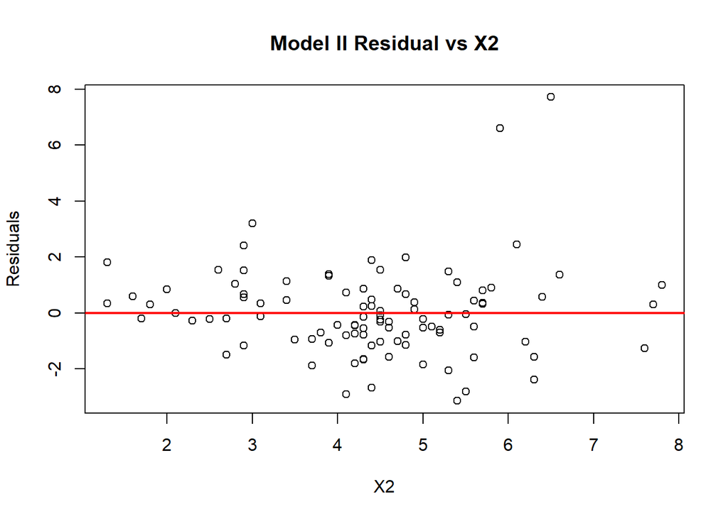

```r
# Residual vs X2
plot(M2_X2, M1_resid,
     main = "Model II Residual vs X2",
     xlab = "X2",
     ylab = "Residuals")
abline( h = 0 , lwd = 2, col = "red")
```

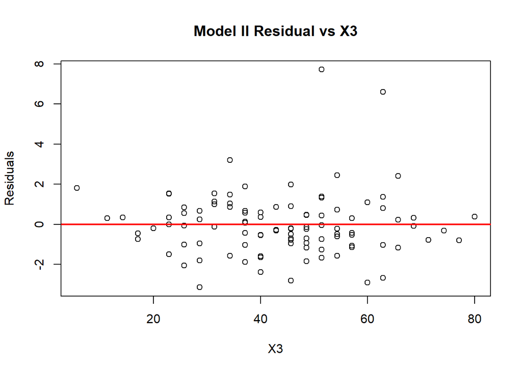

```r
# Residual vs X3
plot(M2_X3, M1_resid,
     main = "Model II Residual vs X3",
     xlab = "X3",
     ylab = "Residuals")
abline( h = 0 , lwd = 2, col = "red")
```

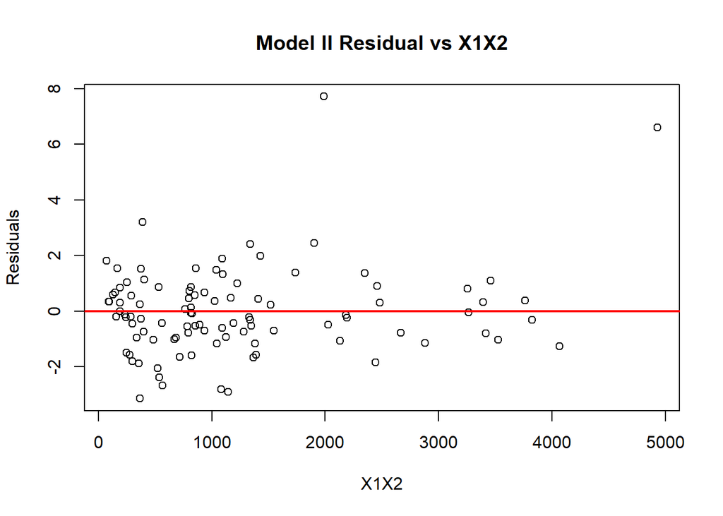

```r
# Residual vs X1X2
plot((M2_X1*M2_X2), M1_resid,
     main = "Model II Residual vs X1X2",
     xlab = "X1X2",
     ylab = "Residuals")
abline( h = 0 , lwd = 2, col = "red")
```

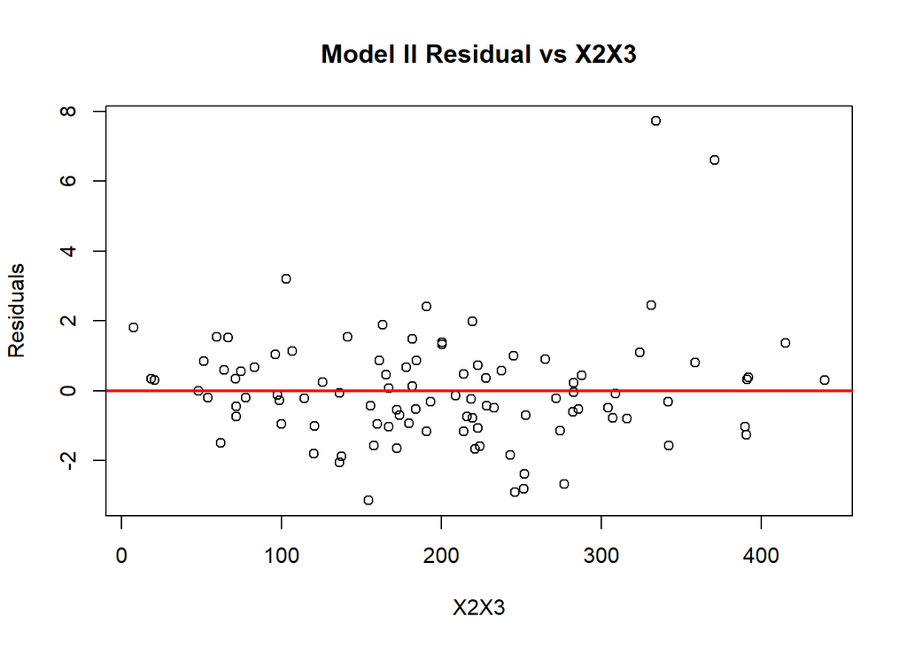

```r
# Residual vs X2X3
plot((M2_X2*M2_X3), M1_resid,
     main = "Model II Residual vs X2X3",
     xlab = "X2X3",
     ylab = "Residuals")

abline( h = 0 , lwd = 2, col = "red")
```

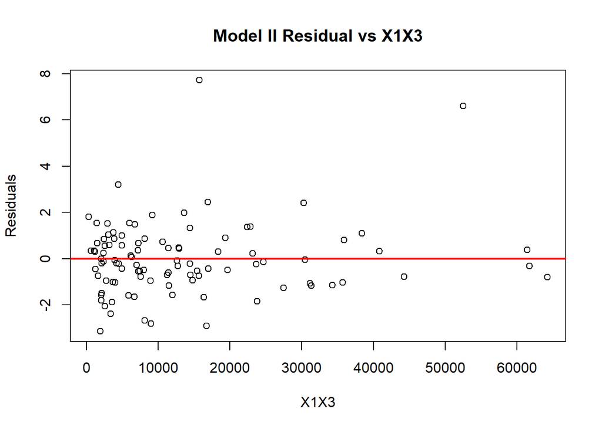

```r
# Residual vs X1X3
plot((M2_X1*M2_X3), M1_resid,
     main = "Model II Residual vs X1X3",
     xlab = "X1X3",
     ylab = "Residuals")

abline( h = 0 , lwd = 2, col = "red")
```

g.Also prepare a normal probability plot of the residuals for each of the two fitted models. Interpret your plots and state your findings.

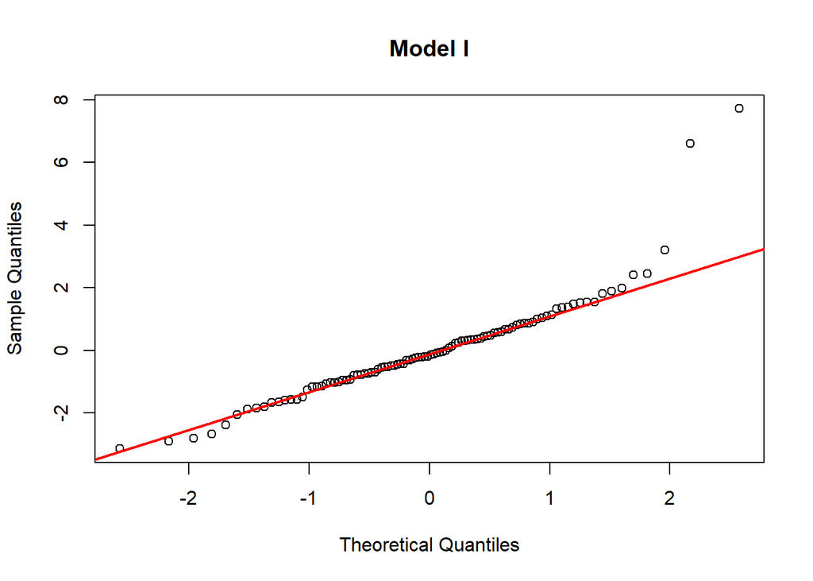

```r
# Model I
qqnorm(M1_resid, main = "Model I")

qqline(M1_resid, col = "red", lwd = 2)
```

There are a few outliers can be observed from the the normal probability plot. Overall, the distribution of residuals in Model I is approximately linear, suggesting it is normally distributed.

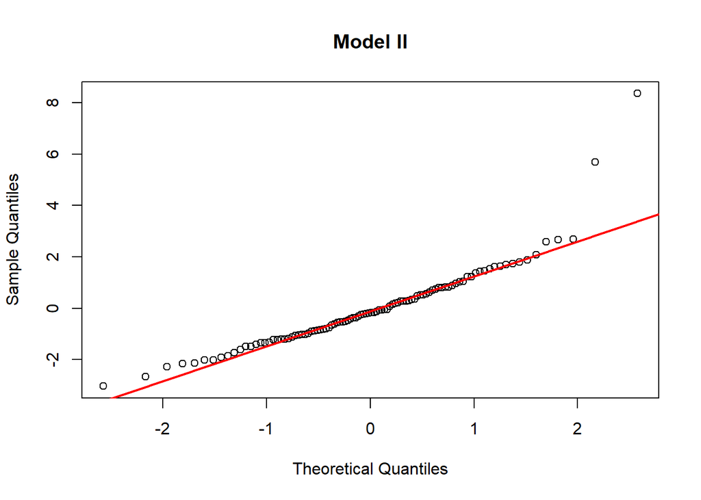

```r
# Model II

qqnorm(M2_resid, main = "Model II")

qqline(M2_resid, col = "red", lwd = 2)
```

There are a few outliers can be observed from the the normal probability plot. Overall, the distribution of residuals in Model II is approximately linear, suggesting it is normally distributed.

h.Is one model clearly more appropriate than the other?  
Yes. Model I is more appropriate than Model II. Model II exhibits multicollinearity as the number of beds(X1) is highly correlated to the available facilities and services(X3).

#Part II  
a.For each geographic region, regress infection risk (Y) against the predictor variables age (X1), routine culturing ratio (X2), average daily census (X3), and available facilities and services (X4). Use first order regression model $Y_{i} = \beta_{0} + \beta_{1}X_{i1} + \beta_{2}X_{i2} + ... + \beta_{p-1}X_{i,p-1} + \epsilon_{i}$ with four predictor variables. State the estimated regression functions.

```r
# NE Region, model & coefficients
NE = senic[senic$Region == "1", c("Infection risk", "Age", "Routine culturing ratio", "Average daily census", "Available facilities and services")]

NE_model = lm(NE$`Infection risk`~ NE$Age + NE$`Routine culturing ratio` + NE$`Average daily census` + NE$`Available facilities and services`, NE)

coef(NE_model)
```

```
##                            (Intercept)                                 NE$Age
##                           -3.349575691                            0.116953966
##           NE$`Routine culturing ratio`              NE$`Average daily census`
##                            0.058240199                            0.001508185
## NE$`Available facilities and services`
##                            0.006613008
```

```r
# NC Region, model & coefficients
NC = senic[senic$Region == "2", c("Infection risk", "Age", "Routine culturing ratio", "Average daily census", "Available facilities and services")]

NC_model = lm(NC$`Infection risk`~ NC$Age + NC$`Routine culturing ratio` + NC$`Average daily census` + NC$`Available facilities and services`, NC)

coef(NC_model)
```

```
##                            (Intercept)                                 NC$Age
##                            2.291536309                            0.004741675
##           NC$`Routine culturing ratio`              NC$`Average daily census`
##                            0.058029857                            0.001172493
## NC$`Available facilities and services`
##                            0.015018013
```

```r
# S Region, model & coefficients
S = senic[senic$Region == "3", c("Infection risk", "Age", "Routine culturing ratio", "Average daily census", "Available facilities and services")]

S_model = lm(S$`Infection risk`~ S$Age + S$`Routine culturing ratio` + S$`Average daily census` + S$`Available facilities and services`, S)

coef(S_model)
```

```
##                           (Intercept)                                 S$Age
##                          -0.143858073                           0.030847623
##           S$`Routine culturing ratio`              S$`Average daily census`
##                           0.102281125                           0.004114042
## S$`Available facilities and services`
##                           0.008038739
```

```r
# W Region, model & coefficients
W = senic[senic$Region == "4", c("Infection risk", "Age", "Routine culturing ratio", "Average daily census", "Available facilities and services")]

W_model = lm(W$`Infection risk`~ W$Age + W$`Routine culturing ratio` + W$`Average daily census` + W$`Available facilities and services`, W)

coef(W_model)
```

```
##                           (Intercept)                                 W$Age
##                          1.5665490073                          0.0352413386
##           W$`Routine culturing ratio`              W$`Average daily census`
##                          0.0403277089                         -0.0006639623
## W$`Available facilities and services`
##                          0.0127922933
```

The estimated regression functions for region NE is: $\hat{Y} =$ -3.3495757 + 0.116954$X_{1}$ + 0.0582402$X_{2}$ + 0.0015082$X_{3}$ + 0.006613$X_{4}$

The estimated regression functions for region NC is: $\hat{Y} =$ 2.2915363 + 0.0047417$X_{1}$ + 0.0580299$X_{2}$ + 0.0011725$X_{3}$ + 0.015018$X_{4}$

The estimated regression functions for region S is: $\hat{Y} =$ -0.1438581 + 0.0308476$X_{1}$ + 0.1022811$X_{2}$ + 0.004114$X_{3}$ + 0.0080387$X_{4}$

The estimated regression functions for region W is: $\hat{Y} =$ 1.566549 + 0.0352413$X_{1}$ + 0.0403277$X_{2}$ -6.64^{-4}$X_{3}$ + 0.0127923$X_{4}$

2. Are the estimated regression functions similar for the four regions? Discuss.  
   No. The estimated regression functions for all four regions have different y-intercept and different coefficients for each predictor variables.
3. Calculate MSE and $R^2$ for each region. Are these measures similar for the four regions? Discuss.

```r
anova(NE_model)
```

|  | Df | Sum Sq | Mean Sq | F value | Pr(>F) |
| --- | --- | --- | --- | --- | --- |
| NE$Age | 1 | 7.36348053 | 7.36348053 | 7.20658609 | 0.013235694 |
| NE$`Routine culturing ratio` | 1 | 10.31117794 | 10.31117794 | 10.09147660 | 0.004206157 |
| NE$`Average daily census` | 1 | 2.36722972 | 2.36722972 | 2.31679091 | 0.141614951 |
| NE$`Available facilities and services` | 1 | 0.08416497 | 0.08416497 | 0.08237166 | 0.776678523 |
| Residuals | 23 | 23.50073255 | 1.02177098 | NA | NA |

```r
NE_model_MSE = anova(NE_model)[[3]][[5]]
summary(NE_model)
```

```
##
## Call:
## lm(formula = NE$`Infection risk` ~ NE$Age + NE$`Routine culturing ratio` +
##     NE$`Average daily census` + NE$`Available facilities and services`,
##     data = NE)
##
## Residuals:
##      Min       1Q   Median       3Q      Max
## -2.67221 -0.62955  0.05195  0.72448  1.54486
##
## Coefficients:
##                                         Estimate Std. Error t value Pr(>|t|)
## (Intercept)                            -3.349576   2.709974  -1.236   0.2289
## NE$Age                                  0.116954   0.050215   2.329   0.0290 *
## NE$`Routine culturing ratio`            0.058240   0.022609   2.576   0.0169 *
## NE$`Average daily census`               0.001508   0.001651   0.913   0.3706
## NE$`Available facilities and services`  0.006613   0.023041   0.287   0.7767
## ---
## Signif. codes:  0 '***' 0.001 '**' 0.01 '*' 0.05 '.' 0.1 ' ' 1
##
## Residual standard error: 1.011 on 23 degrees of freedom
## Multiple R-squared:  0.4613, Adjusted R-squared:  0.3676
## F-statistic: 4.924 on 4 and 23 DF,  p-value: 0.005128
```

```r
anova(NC_model)
```

|  | Df | Sum Sq | Mean Sq | F value | Pr(>F) |
| --- | --- | --- | --- | --- | --- |
| NC$Age | 1 | 2.2403352 | 2.2403352 | 1.8485879 | 0.185194869 |
| NC$`Routine culturing ratio` | 1 | 15.8258490 | 15.8258490 | 13.0585252 | 0.001218092 |
| NC$`Average daily census` | 1 | 4.2200536 | 4.2200536 | 3.4821308 | 0.072933467 |
| NC$`Available facilities and services` | 1 | 0.5907525 | 0.5907525 | 0.4874529 | 0.491035595 |
| Residuals | 27 | 32.7217597 | 1.2119170 | NA | NA |

```r
NC_model_MSE = anova(NC_model)[[3]][[5]]
summary(NC_model)
```

```
##
## Call:
## lm(formula = NC$`Infection risk` ~ NC$Age + NC$`Routine culturing ratio` +
##     NC$`Average daily census` + NC$`Available facilities and services`,
##     data = NC)
##
## Residuals:
##      Min       1Q   Median       3Q      Max
## -1.98794 -0.70073  0.09807  0.59809  2.07417
##
## Coefficients:
##                                        Estimate Std. Error t value Pr(>|t|)
## (Intercept)                            2.291536   2.686553   0.853  0.40118
## NC$Age                                 0.004742   0.047213   0.100  0.92074
## NC$`Routine culturing ratio`           0.058030   0.016192   3.584  0.00132 **
## NC$`Average daily census`              0.001172   0.002094   0.560  0.58016
## NC$`Available facilities and services` 0.015018   0.021510   0.698  0.49104
## ---
## Signif. codes:  0 '***' 0.001 '**' 0.01 '*' 0.05 '.' 0.1 ' ' 1
##
## Residual standard error: 1.101 on 27 degrees of freedom
## Multiple R-squared:  0.4115, Adjusted R-squared:  0.3243
## F-statistic: 4.719 on 4 and 27 DF,  p-value: 0.005111
```

```r
anova(S_model)
```

|  | Df | Sum Sq | Mean Sq | F value | Pr(>F) |
| --- | --- | --- | --- | --- | --- |
| S$Age | 1 | 1.1019827 | 1.1019827 | 1.176427 | 2.861890e-01 |
| S$`Routine culturing ratio` | 1 | 28.8269995 | 28.8269995 | 30.774392 | 4.038379e-06 |
| S$`Average daily census` | 1 | 16.5829421 | 16.5829421 | 17.703194 | 1.948299e-04 |
| S$`Available facilities and services` | 1 | 0.1459972 | 0.1459972 | 0.155860 | 6.956163e-01 |
| Residuals | 32 | 29.9750515 | 0.9367204 | NA | NA |

```r
S_model_MSE = anova(S_model)[[3]][[5]]
summary(S_model)
```

```
##
## Call:
## lm(formula = S$`Infection risk` ~ S$Age + S$`Routine culturing ratio` +
##     S$`Average daily census` + S$`Available facilities and services`,
##     data = S)
##
## Residuals:
##     Min      1Q  Median      3Q     Max
## -1.9122 -0.4960  0.1105  0.4411  2.3904
##
## Coefficients:
##                                        Estimate Std. Error t value Pr(>|t|)
## (Intercept)                           -0.143858   2.323190  -0.062   0.9510
## S$Age                                  0.030848   0.039175   0.787   0.4368
## S$`Routine culturing ratio`            0.102281   0.021215   4.821 3.34e-05 ***
## S$`Average daily census`               0.004114   0.002160   1.905   0.0658 .
## S$`Available facilities and services`  0.008039   0.020362   0.395   0.6956
## ---
## Signif. codes:  0 '***' 0.001 '**' 0.01 '*' 0.05 '.' 0.1 ' ' 1
##
## Residual standard error: 0.9678 on 32 degrees of freedom
## Multiple R-squared:  0.6088, Adjusted R-squared:   0.56
## F-statistic: 12.45 on 4 and 32 DF,  p-value: 3.225e-06
```

```r
anova(W_model)
```

|  | Df | Sum Sq | Mean Sq | F value | Pr(>F) |
| --- | --- | --- | --- | --- | --- |
| W$Age | 1 | 0.01467799 | 0.01467799 | 0.01538889 | 0.9035119 |
| W$`Routine culturing ratio` | 1 | 0.67117167 | 0.67117167 | 0.70367870 | 0.4194066 |
| W$`Average daily census` | 1 | 0.11338643 | 0.11338643 | 0.11887811 | 0.7367566 |
| W$`Available facilities and services` | 1 | 0.23329310 | 0.23329310 | 0.24459224 | 0.6306376 |
| Residuals | 11 | 10.49184581 | 0.95380416 | NA | NA |

```r
W_model_MSE = anova(W_model)[[3]][[5]]
summary(W_model)
```

```
##
## Call:
## lm(formula = W$`Infection risk` ~ W$Age + W$`Routine culturing ratio` +
##     W$`Average daily census` + W$`Available facilities and services`,
##     data = W)
##
## Residuals:
##      Min       1Q   Median       3Q      Max
## -1.69113 -0.42384 -0.01758  0.77365  1.11734
##
## Coefficients:
##                                        Estimate Std. Error t value Pr(>|t|)
## (Intercept)                            1.566549   4.382848   0.357    0.728
## W$Age                                  0.035241   0.074383   0.474    0.645
## W$`Routine culturing ratio`            0.040328   0.058780   0.686    0.507
## W$`Average daily census`              -0.000664   0.003173  -0.209    0.838
## W$`Available facilities and services`  0.012792   0.025866   0.495    0.631
##
## Residual standard error: 0.9766 on 11 degrees of freedom
## Multiple R-squared:  0.0896, Adjusted R-squared:  -0.2415
## F-statistic: 0.2706 on 4 and 11 DF,  p-value: 0.8908
```

The MSE for region 1 (NE): 1.022 and $R^2 =$ 0.4613  
The MSE for region 2 (NC): 1.212 and $R^2 =$ 0.4115  
The MSE for region 3 (S): 0.9367 and $R^2 =$ 0.6088  
The MSE for region 4 (W): 0.9538 and $R^2 =$ 0.0896  
No. Region 3 (S) has the highest $R^2$ and the lowest MSE. The mutliple regression model fits well for region 3.

4. Obtain the residuals for each fitted model and prepare a box plot of the residuals for each fitted model. Interpret the plots and state your findings.

```r
# residual for NE
NE_model_resid = resid(NE_model)
cat(paste(NE_model_resid),sep="\n")
```

```
## -0.0342273584097477
## 0.98765428656916
## -1.05259892258066
## 0.969875900275707
## 1.54486435405277
## 0.468288627983917
## 0.138136954674223
## -0.653339532235396
## -0.280301890475128
## 0.581428177849706
## 0.840642181291366
## 0.976450661371726
## -0.0432156344096429
## 1.09065860386326
## 0.378648317977297
## -0.621623801079508
## -0.473957658037715
## -0.808372765533425
## -0.66898998592778
## -1.19173015228374
## -1.04027681582785
## -0.547621813036081
## 0.26281654092046
## -2.6722081750625
## 0.685757841433412
## 1.17966996528679
## 0.453283064633624
## -0.469710973284251
```

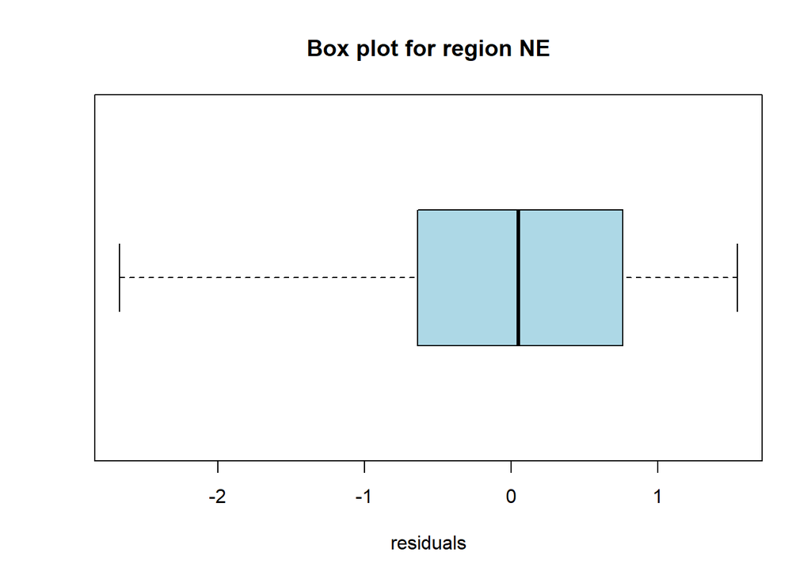

```r
boxplot(NE_model_resid,
        main = "Box plot for region NE",
        xlab = "residuals",
        col = "lightblue",
        horizontal = TRUE
        )
```

```r
# residual for NC
NC_model_resid = resid(NC_model)
cat(paste(NC_model_resid),sep="\n")
```

```
## -1.84853289053221
## 0.5231815998647
## -1.98794265700656
## -0.693755651579362
## 0.579762200007206
## -0.578646807065985
## -0.664375623647415
## 0.652220667321446
## 0.580049767541949
## 2.07417431035728
## -1.32101427141347
## 0.212979490058248
## 1.46413277744977
## 1.02726568956321
## -0.465878785550009
## 1.65408570868722
## -0.961879520761949
## 0.405260123195279
## 0.780027152665538
## 0.438281394896963
## 0.3453324699669
## -0.721640367473396
## 0.0538420108308836
## 0.102320492143733
## 0.0938149611918229
## -1.11387716199482
## -0.235334033753942
## -0.310999129139277
## -1.50728064519864
## 1.32918330391934
## -1.06834405635197
## 1.16358748180751
```

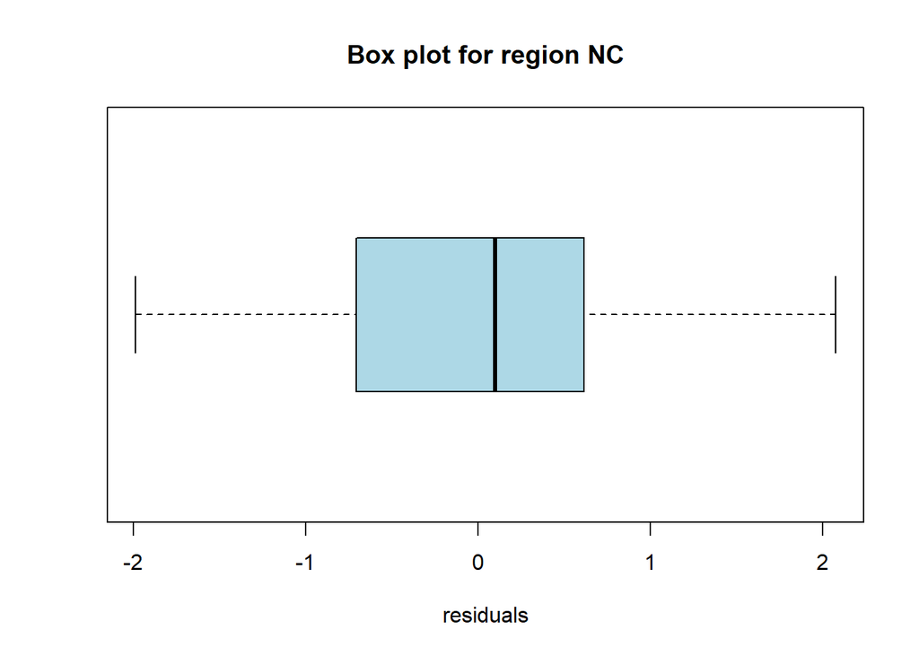

```r
boxplot(NC_model_resid,
        main = "Box plot for region NC",
        xlab = "residuals",
        col = "lightblue",
        horizontal = TRUE
        )
```

```r
# residual for S
S_model_resid = resid(S_model)
cat(paste(S_model_resid),sep="\n")
```

```
## -0.237975023495878
## 0.31000074622379
## -0.395031847530003
## 1.23033840591245
## 0.725413469297601
## 0.392688698927543
## -1.91218183954782
## -0.586621365302549
## 2.02161295312011
## -0.945638331926105
## 0.157678058211631
## 0.165341319125445
## 0.373184412909202
## 0.900848445918977
## -0.380914398965148
## 0.329832889456119
## 2.39037650073211
## 0.411177911447086
## -0.396657536725615
## -0.020606708489233
## 0.268947064947382
## -1.16211427771229
## 0.838821718003696
## -1.30703515332444
## -0.322157011447439
## -1.76598770922419
## 0.110535546496126
## 0.0156959994533171
## -0.667075861167059
## 0.519922043931915
## -0.496001272138083
## 0.700272193710746
## 0.61840198360407
## 0.441089137962255
## -1.02466756571186
## -0.336578976004038
## -0.964934620679823
```

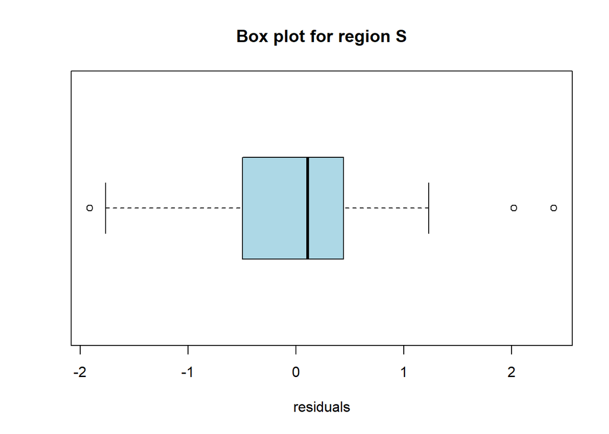

```r
boxplot(S_model_resid,
        main = "Box plot for region S",
        xlab = "residuals",
        col = "lightblue",
        horizontal = TRUE
        )
```

```r
# residual for W
W_model_resid = resid(W_model)
cat(paste(W_model_resid),sep="\n")
```

```
## -0.422538344109108
## 0.902295681866005
## -0.228999072560954
## 0.0342027089043789
## -0.680314928120642
## 0.219912406719995
## -0.427751431745283
## -0.0693643405590041
## 0.934050200539863
## 0.36446421062787
## 1.11733991754851
## 0.730768812529076
## 1.01042667366306
## -1.3813866998024
## -1.69112812138974
## -0.411977674111629
```

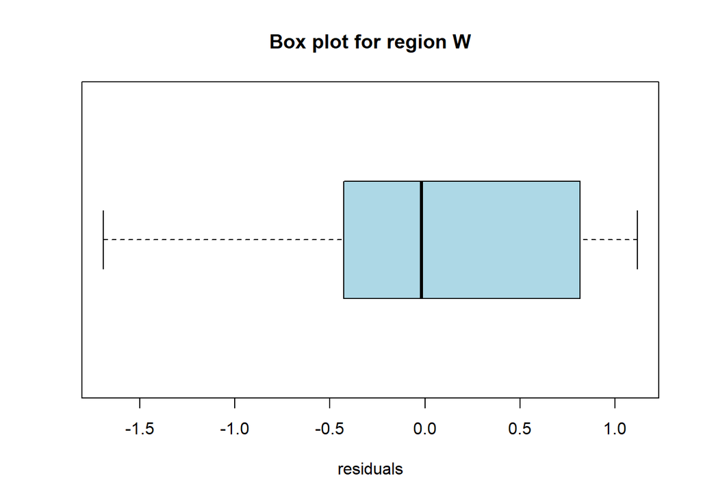

```r
boxplot(W_model_resid,
        main = "Box plot for region W",
        xlab = "residuals",
        col = "lightblue",
        horizontal = TRUE
        )
```

The boxplot for region NE is left skewed. The model may not normally distributed.  
The boxplot for region NC is left skewed. The model may not normally distributed.  
The boxplot for region S is left skewed. The model may not normally distributed. It is observed that there are a few outliers.  
The boxplot for region W is not perfectly symmetric. The model may not normally distributed.

5. Now perform part (a) using a set of indicator/dummy variables to represent the geographic regions. Interpret the results. What can you conclude about the differences in infection risk for the four geographic regions?

```r
dummy_NE = rep(0, 113)
dummy_NC = rep(0, 113)
dummy_S = rep(0, 113)

senic = data.table(senic)
senic= senic[ , `:=` (NE = dummy_NE, NC = dummy_NC, S = dummy_S)]

senic$NE[senic$Region == 1] = 1
senic$NC[senic$Region == 2] = 1
senic$S[senic$Region == 3] = 1

region_sample_dummy = senic[ , c(4, 3, 5, 10, 12, 13:15)]
colnames(region_sample_dummy) = c("Y", "X1", "X2", "X3", "X4", "X5", "X6", "X7")
knitr::kable(region_sample_dummy)
```

| Y | X1 | X2 | X3 | X4 | X5 | X6 | X7 |
| --- | --- | --- | --- | --- | --- | --- | --- |
| 4.1 | 55.7 | 9.0 | 207 | 60.0 | 0 | 0 | 0 |
| 1.6 | 58.2 | 3.8 | 51 | 40.0 | 0 | 1 | 0 |
| 2.7 | 56.9 | 8.1 | 82 | 20.0 | 0 | 0 | 1 |
| 5.6 | 53.7 | 18.9 | 53 | 40.0 | 0 | 0 | 0 |
| 5.7 | 56.5 | 34.5 | 134 | 40.0 | 1 | 0 | 0 |
| 5.1 | 50.9 | 21.9 | 147 | 40.0 | 0 | 1 | 0 |
| 4.6 | 57.8 | 16.7 | 151 | 40.0 | 0 | 0 | 1 |
| 5.4 | 45.7 | 60.5 | 399 | 60.0 | 0 | 1 | 0 |
| 4.3 | 48.2 | 24.4 | 130 | 40.0 | 0 | 0 | 1 |
| 6.3 | 56.3 | 29.6 | 59 | 40.0 | 1 | 0 | 0 |
| 4.9 | 53.2 | 28.5 | 591 | 80.0 | 1 | 0 | 0 |
| 4.3 | 57.2 | 6.8 | 105 | 40.0 | 0 | 0 | 1 |
| 7.7 | 56.8 | 46.0 | 252 | 57.1 | 1 | 0 | 0 |
| 3.7 | 56.7 | 20.8 | 59 | 37.1 | 0 | 1 | 0 |
| 4.2 | 56.3 | 14.6 | 61 | 17.1 | 0 | 0 | 1 |
| 5.5 | 50.2 | 18.6 | 326 | 57.1 | 0 | 0 | 1 |
| 4.5 | 48.1 | 26.0 | 84 | 37.1 | 0 | 0 | 0 |
| 6.4 | 53.9 | 25.5 | 113 | 37.1 | 1 | 0 | 0 |
| 4.2 | 52.8 | 6.9 | 103 | 37.1 | 0 | 1 | 0 |
| 4.1 | 53.8 | 15.9 | 547 | 77.1 | 0 | 0 | 1 |
| 4.2 | 42.0 | 23.1 | 47 | 17.1 | 0 | 0 | 0 |
| 4.8 | 49.0 | 36.3 | 163 | 37.1 | 0 | 1 | 0 |
| 5.0 | 52.3 | 17.6 | 240 | 57.1 | 1 | 0 | 0 |
| 4.8 | 62.2 | 12.0 | 468 | 57.1 | 0 | 0 | 1 |
| 4.0 | 52.2 | 17.5 | 244 | 57.1 | 0 | 0 | 0 |
| 3.9 | 49.5 | 12.0 | 413 | 57.1 | 0 | 1 | 0 |
| 4.5 | 47.2 | 30.2 | 124 | 37.1 | 1 | 0 | 0 |
| 3.2 | 52.1 | 10.8 | 156 | 37.1 | 1 | 0 | 0 |
| 4.4 | 54.5 | 18.6 | 217 | 37.1 | 1 | 0 | 0 |
| 4.9 | 50.5 | 17.7 | 113 | 37.1 | 0 | 1 | 0 |

[output cut: 83 more lines]

```r
region_sample_model = lm(Y ~ X1 + X2 + X3 + X4 + X5 + X6 + X7, region_sample_dummy)
```

The regression function for NE region:  
$Y$ = 0.4120679 + 0.0431869 $X1$ + 0.0698339 $X2$ + 0.0018174 $X3$ + 0.013797 $X4$  
-0.40823 $X5$

$Y$ = 0.0038379 + 0.0431869 $X1$ + 0.0698339 $X2$ + 0.0018174 $X3$ + 0.013797 $X4$

NC region:  
$Y$ = 0.4120679 + 0.0431869 $X1$ + 0.0698339 $X2$ + 0.0018174 $X3$ + 0.013797 $X4$ -0.3796959 $X6$  
$Y$ = 0.0323721 + 0.0431869 $X1$ + 0.0698339 $X2$ + 0.0018174 $X3$ + 0.013797 $X4$

S region:  
$Y$ = 0.4120679 + 0.0431869 $X1$ + 0.0698339 $X2$ + 0.0018174 $X3$ + 0.013797 $X4$ -0.5912536 $X7$  
$Y$ = -0.1791857 + 0.0431869 $X1$ + 0.0698339 $X2$ + 0.0018174 $X3$ + 0.013797 $X4$

W region:  
$Y$ = 0.4120679 + 0.0431869 $X1$ + 0.0698339 $X2$ + 0.0018174 $X3$ + 0.013797 $X4$

Based on all regression functions of all four regions, the infection risk in W region is higher followed by NC, NE, and S region.

#Part III  
a. For each of the following variables, calculate the coefficient of partial determination given that $X_{1}$ and $X_{2}$ are included in the model: routine culturing ratio ($X_{3}$), average daily census ($X_{4}$), number of nurses ($X_{5}$), and available facilities and services ($X_{6}$).

```r
dataset0 = senic[, c(2, 3, 4)]
dataset1 = senic[, c(2, 3, 4, 5)]
dataset2 = senic[, c(2, 3, 4, 10)]
dataset3 = senic[, c(2, 3, 4, 11)]
dataset4 = senic[, c(2, 3, 4, 12)]

colnames(dataset0) = c("Y", "X1", "X2")
colnames(dataset1) = c("Y", "X1", "X2", "X3")
colnames(dataset2) = c("Y", "X1", "X2", "X4")
colnames(dataset3) = c("Y", "X1", "X2", "X5")
colnames(dataset4) = c("Y", "X1", "X2", "X6")

dataset0_model = lm(Y ~ X1 + X2, dataset0)
anova(dataset0_model)
```

|  | Df | Sum Sq | Mean Sq | F value | Pr(>F) |
| --- | --- | --- | --- | --- | --- |
| X1 | 1 | 14.6041 | 14.604100 | 5.77340 | 1.794427e-02 |
| X2 | 1 | 116.3559 | 116.355852 | 45.99865 | 6.188208e-10 |
| Residuals | 110 | 278.2504 | 2.529549 | NA | NA |

```r
dataset1_model = lm(Y ~ X1 + X2 + X3, dataset1)
anova(dataset1_model)
```

|  | Df | Sum Sq | Mean Sq | F value | Pr(>F) |
| --- | --- | --- | --- | --- | --- |
| X1 | 1 | 14.604100 | 14.604100 | 5.788483 | 1.781433e-02 |
| X2 | 1 | 116.355852 | 116.355852 | 46.118821 | 6.100213e-10 |
| X3 | 1 | 3.247997 | 3.247997 | 1.287377 | 2.590210e-01 |
| Residuals | 109 | 275.002432 | 2.522958 | NA | NA |

```r
dataset2_model = lm(Y ~ X1 + X2 + X4, dataset2)
anova(dataset2_model)
```

|  | Df | Sum Sq | Mean Sq | F value | Pr(>F) |
| --- | --- | --- | --- | --- | --- |
| X1 | 1 | 14.60410 | 14.604100 | 6.622987 | 1.141016e-02 |
| X2 | 1 | 116.35585 | 116.355852 | 52.767603 | 5.927950e-11 |
| X4 | 1 | 37.89864 | 37.898637 | 17.187105 | 6.722471e-05 |
| Residuals | 109 | 240.35179 | 2.205062 | NA | NA |

```r
dataset3_model = lm(Y ~ X1 + X2 + X5, dataset3)
anova(dataset3_model)
```

|  | Df | Sum Sq | Mean Sq | F value | Pr(>F) |
| --- | --- | --- | --- | --- | --- |
| X1 | 1 | 14.6041 | 14.604100 | 5.942982 | 1.639264e-02 |
| X2 | 1 | 116.3559 | 116.355852 | 47.349767 | 3.930753e-10 |
| X5 | 1 | 10.3972 | 10.397202 | 4.231030 | 4.207858e-02 |
| Residuals | 109 | 267.8532 | 2.457369 | NA | NA |

```r
dataset4_model = lm(Y ~ X1 + X2 + X6, dataset4)
anova(dataset4_model)
```

|  | Df | Sum Sq | Mean Sq | F value | Pr(>F) |
| --- | --- | --- | --- | --- | --- |
| X1 | 1 | 14.6041 | 14.604100 | 5.936953 | 1.644583e-02 |
| X2 | 1 | 116.3559 | 116.355852 | 47.301732 | 3.998472e-10 |
| X6 | 1 | 10.1252 | 10.125197 | 4.116160 | 4.491281e-02 |
| Residuals | 109 | 268.1252 | 2.459865 | NA | NA |

SSE(X1, X2) = 278.2504287  
SSR(X3|X1, X2) = 3.2479972  
SSR(X4|X1, X2) = 37.8986373  
SSR(X5|X1, X2) = 10.3972018  
SSR(X6|X1, X2) = 10.125197

$R^2_{Y3|12}$ = 0.01167

$R^2_{Y4|12}$ = 0.1362

$R^2_{Y5|12}$ = 0.03737

$R^2_{Y6|12}$ = 0.03639

2. On the basis of the results in part (a), which of the four additional predictor variables is best? Is the extra sum of squares associated with this variable larger than those for the other three variables?  
   X4. Yes.
3. Using the F* test statistic, test whether or not the variable determined to be the best in part (b) is helpful in the regression model when X1 and X2 are included in the model; use $\alpha$ = .05. State the alternatives, decision rule, and conclusion.

```r
n = nrow(senic)
p = 2
alpha = .05

F_test_statistic = (anova(dataset2_model)[[2]][[3]] / 1) / (anova(dataset2_model)[[2]][[4]] / (n-4) )
F_test_statistic
```

```
## [1] 17.1871
```

```r
F_distribution = qf(1-alpha, p-1, n-p)
F_distribution
```

```
## [1] 3.926607
```

```r
if(F_test_statistic <= F_distribution){
 print("conclude H0")
}else{
 print("conclude Ha")
}
```

```
## [1] "conclude Ha"
```

Full model: $Y_{i} = \beta_{0} + \beta_{1}X_{i1} + \beta_{2}X_{i2} + \beta_{4}X_{i4} + \epsilon_{i}$  
$H_{0}: \beta_{4} = 0,$  
$H_{a}: \beta_{4} \neq 0$  
$SSR(X_{4} | X_{1}, X_{2}) =$ 37.8986373,  
$SSE(X_{1}, X_{2}, X_{4}) =$ 240.3517914

$F* = \frac{SSR(X_{4} | X_{1}, X_{2})}{1} ÷ \frac{SSE(X_{1}, X_{2}, X_{4})}{n-4}$ = 17.19

$F(.95, 1, 109) =$ 3.93

Decision rule:  
If $F* \leq$ 3.93 conclude $H_{0},$  
otherwise conclude $H_{a}$

Conclusion:  
Since $F^* =$ 17.2 $>$ 3.927, we conclude $H_{a}$. The predictor variable $X_{4}$ should not be dropped from the model that already contains $X_{1}$ and $X_{2}$.